# Stress Testing the Sharpe Ratio

Adding roster context, class depth, and prospect talent to our NFL Draft model

Nick Gurol — [X/Twitter](https://x.com/run_the_sims) | [LinkedIn](https://www.linkedin.com/in/nick-gurol-87738a1b7/)

## TL;DR

[Part 1](https://stranger9977.github.io/draft-sharpe-analysis/) built the case that RB is the worst first-round investment by Sharpe ratio. That positional hierarchy holds up — we validated it here. But the model deliberately strips away context to isolate position economics. This article adds three layers back in: roster context (9 teams enter 2026 needing an RB), class depth (2026 is the thinnest RB class in years, with Jeremiyah Love as the only Elite prospect), and prospect separation (Love’s 94.3 Prospect Score ranks 5th all-time among RBs). QB is still king. Premium positions still generate more surplus. But Love’s 90th-percentile outcome crosses the premium surplus line at a mid-first-round pick, meaning teams drafting after that point who need a back can justify the gamble. The framework has room for this kind of exception — elite talent, genuine need, no alternative.

## Building on the Foundation

In [Part 1](https://stranger9977.github.io/draft-sharpe-analysis/), I built a quasi-Sharpe ratio for NFL draft picks. The main takeaway was that QB and other premium positions like OT, EDGE, and WR are better risk-adjusted bets in the first round than non-premium positions.

The framework in Part 1 was a bit reductive, and GMs don’t operate in the aggregate. They need to draft in specific years, with specific rosters, in drafts with specific prospects.

In this article, I will take the Sharpe ratio as constructed in the last article and stress test it a little before layering in some extra dimensions to help round out our final hot take: where exactly does it make sense to take Jeremiyah Love in this year’s draft?

The first article had to make a few simplifications to build the foundation:

| Part 1 Simplification | What Context Adds |
| --- | --- |
| Teams should always draft the highest-Sharpe position | Roster needs make some positions more or less valuable for specific teams |
| All draft classes are interchangeable | Class depth varies wildly — scarcity changes the calculus |
| All prospects at a position are interchangeable | Elite prospects separate from the pack and break the averages |

## Quick Recap: What Part 1 Found

The quasi-Sharpe ratio measured risk-adjusted returns by position and draft tier from 2010-2022. ([Full methodology here.](https://stranger9977.github.io/draft-sharpe-analysis/))

**The hierarchy:** QB leads the top 10 (0.37). OT and EDGE peak in the late first (0.59 for EDGE). RB was the worst first-round investment: Sharpe of **-0.62** in the top 10, negative across every tier.

One of the main components of the Sharpe ratio was contract value. We focused a lot on surplus value, which gives us a sense of the advantage teams get when they draft a player that hits big on a cost-controlled rookie contract. This is mainly determined by a market and we assume that market is efficient.

A valid argument I’ve seen is that Saquon Barkley and Jakobi Meyers basically make the same in terms of APY, which shows the market doesn’t reflect actual player impact on the field. I think that’s fair, and as I said in Part 1, it warrants a follow-up investigation.

To take a look at player value from another angle, we introduce **[weighted career Approximate Value](https://www.pro-football-reference.com/about/approximate_value.htm)** (career AV) and define “elite” using the same framework in the [original Brill paper](https://operations.nfl.com/gameday/analytics/big-data-bowl/) we referenced in Part 1. This should help us understand value under a different lens before we return to using rookie surplus alongside it as a way to determine where to take a prospect like Love.

We define an **elite outcome** as finishing in the **top 10% of weighted career AV at their position**, a stricter bar than Part 1’s snap-based “hit.” It doesn’t just ask whether a player became a starter, but whether they became *great*.

## Assumption 1: Teams Should Always Draft the Highest-Sharpe Position

Part 1’s framework ranks positions in the abstract — which is exactly what a general model should do. But a specific team might already have a franchise QB. For them, QB’s league-leading Sharpe is irrelevant. The question shifts from “which position has the best average return?” to “which position fills a real hole on *this* roster?”

We added a quality gate: a position is only “filled” when the starter plays above the snap threshold, earned a second contract above the free-agent replacement cost, and isn’t on an expiring deal. A replacement-level player who plays a lot doesn’t count. With that filter in place, we re-ranked every team’s draft efficiency.

### How Need-Adjustment Changes the Rankings

In Part 1, we ranked teams by “draft efficiency,” the average Sharpe ratio of their first-round picks. A team that spent top-10 picks on high-Sharpe positions (QB, OT, EDGE) scored well; a team that spent them on low-Sharpe positions (RB, S) scored poorly. It’s a clean metric, but it ignores one obvious thing: whether the team actually needed a player at that position.

The need-adjusted version gives partial credit to teams that drafted low-Sharpe positions to fill genuine roster holes, and penalizes teams that drafted high-Sharpe positions they already had covered. The chart shows every team’s original rank vs their need-adjusted rank.

[figure not shown]

**Biggest climber:** DAL moved up 4 spots: they addressed real needs with their first-round picks. **Biggest faller:** IND dropped 7 spots: they kept drafting positions they already had filled.

**The takeaway:** Picks that fill genuine roster needs perform better. Picks addressing real needs average a need-adjusted Sharpe of **0.057** (n=256), while picks at already-filled positions average **-0.139** (n=32). A player drafted into opportunity has a clearer path to snaps, production, and a second contract. The Sharpe ratio tells you which positions have the best *average* returns. But if you already have a franchise QB, that average is irrelevant to you. Roster context turns a general truth into specific advice.

## Assumption 2: All Draft Classes Are Interchangeable

The Sharpe ratio averages across 13 draft classes (2010-2022). But class quality varies wildly. If a GM could know whether this year’s class is loaded or barren *before* the draft, the model’s one-size-fits-all advice starts to crack.

We actually can measure this – at least partially. NFL Next Gen Stats publishes composite prospect scores before the draft, combining athletic testing, college production, and size. These scores exist before a single snap is played in the NFL.

### Prospective Class Quality: What Teams Know Before the Draft

NGS uses four tiers: **Below Average** (50-60), **Average** (60-70), **Good** (70-90), and **Elite** (90+). Instead of looking at mean scores (which compress into a narrow band), we count how many prospects in each class grade as Good or better. A class with five Good+ prospects is fundamentally different from one with two, even if their averages are similar.

We’ll start with RB – the position at the center of the Sharpe debate – then see how the pattern plays out across every position group.

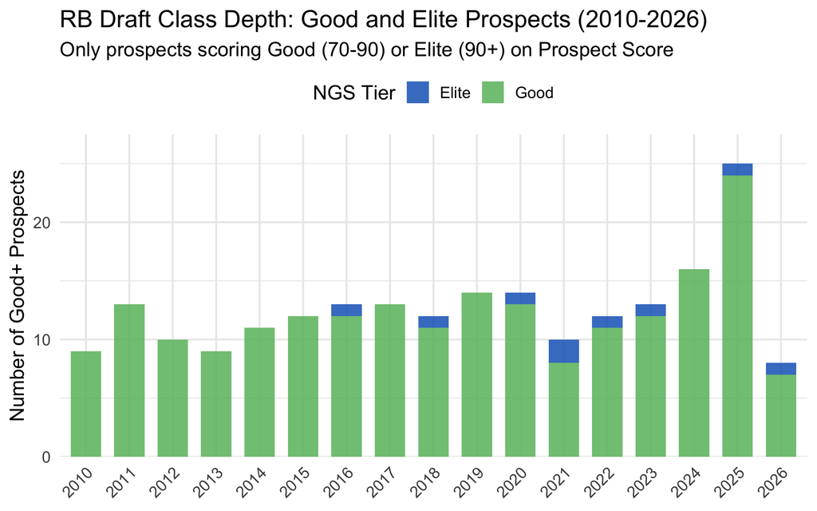

The variation is striking. Some RB classes are loaded with Good+ talent; others barely register. A GM drafting RB in a deep year is playing a fundamentally different game than one drafting in a thin year – but the Sharpe ratio treats them identically.

Now the same view across every position:

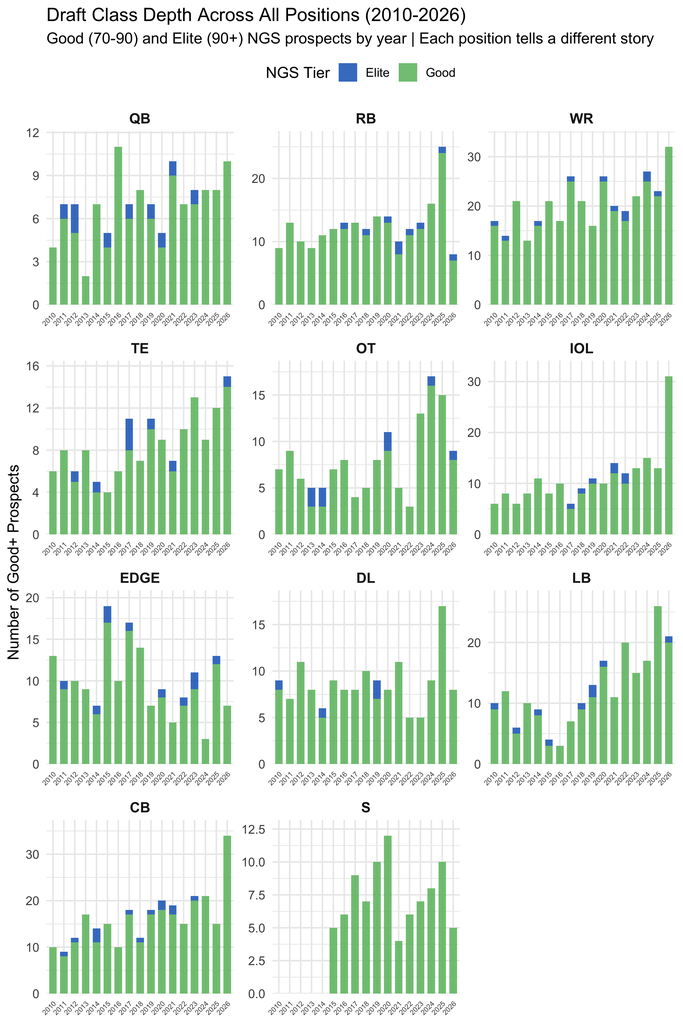

### The 2026 Class at a Glance

Applying the same framework to the 2026 draft class: **CB** (34 Good+), **WR** (32), and **IOL** (31) are the deepest classes this year.

The RB class stands out as especially thin. Only 8 RB prospects grade as Good or better — and Love is the only one in the Elite tier. That 17-point gap to RB2 isn’t just a Love story; it’s a class story. If you pass on Love, the next RB option is a significant downgrade.

This is supply and demand. When a class is deep (IOL, CB, WR this year), supply is high and quality players will be available in later rounds, so the marginal cost of waiting is low. Passing on a premium position in round 1 costs less than usual.

In 2026, the RB market is tight, which reshapes the calculus for teams that need one.

### Did the Pre-Draft Signal Match Reality?

The NGS scores tell us what the class looked like before the draft. But did the “deep” classes actually produce more hits? Here’s the RB timeline with retrospective hit rates: the percentage of ALL drafted RBs that season who became starters (75%+ of positional snap baseline, from Article 1). Bar color is the pre-draft NGS classification, bar height is what actually happened.

**Why stop at 2022?** Hit rates require a full four-year rookie contract to evaluate. A player drafted in 2023 has only played two seasons, which isn’t enough to know if they’ll become a starter. The 2022 class is the most recent with enough NFL tape to judge.

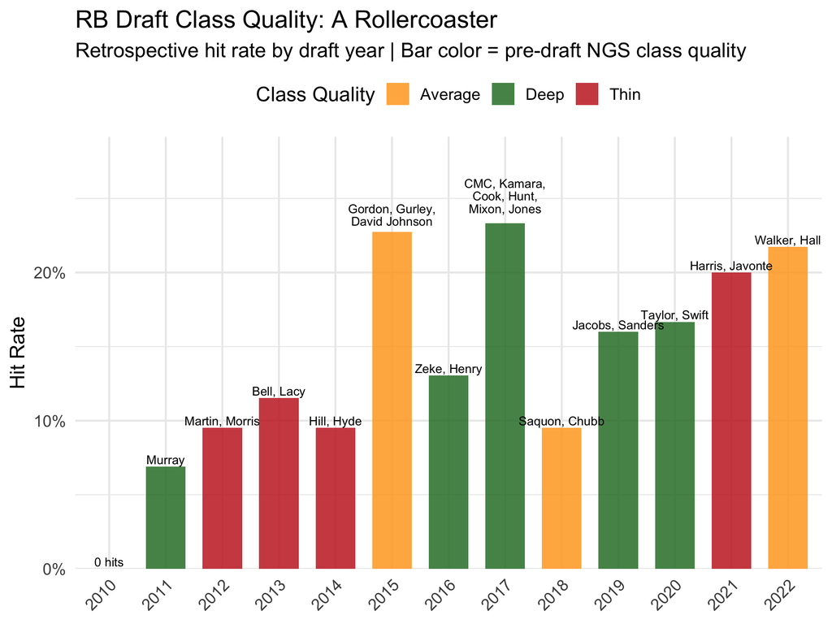

The colors (pre-draft class depth) and heights (what actually happened) track each other. The correlation between a class’s Good+ prospect count and its eventual hit rate is **0.42**.

The [2010 class](https://www.nfldrafthead.com/new-page-1) was unique in that it produced zero hits by our definition, despite having the highest mean NGS score. The only names that probably ring a bell are [C.J. Spiller](https://www.pro-football-reference.com/players/S/SpilC.00.htm) and [Ryan Mathews](https://www.pro-football-reference.com/players/M/MathRy00.htm), who unfortunately miss the hit threshold due to injuries and not quite making the transition to the NFL. Meanwhile, 2017 was the best actual class (23.3% hit rate) because six different backs all found NFL roles.

The NGS tier breakdown gives GMs a real window into which kind of year it is before the first pick is made.

The same signal-vs-reality check across other positions:

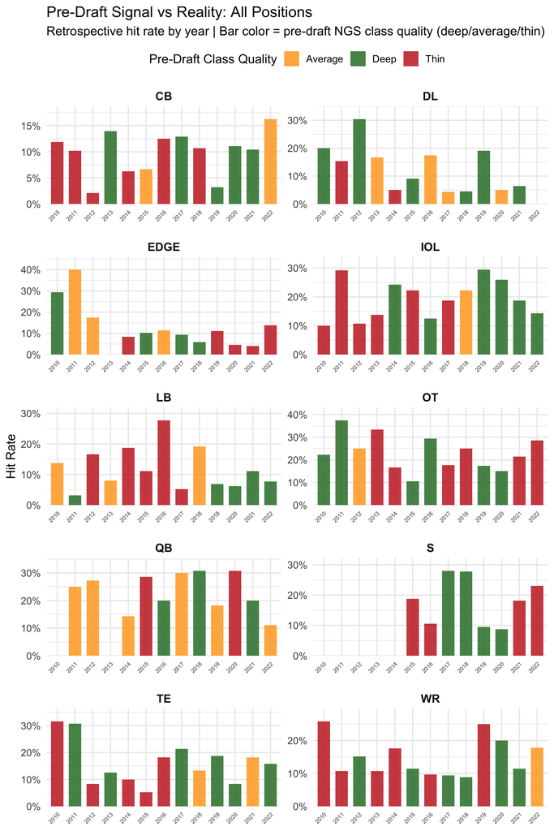

The pre-draft signal isn’t equally predictive everywhere. **DL** shows the strongest correlation (r = 0.45) between Good+ prospect count and eventual hit rate, while **LB** shows the weakest (r = -0.57). Positions where athleticism translates more directly (RB, EDGE) tend to have stronger pre-draft signals. Positions where scheme fit and development matter more (IOL, S) show weaker connections between prospect scores and career outcomes.

## Assumption 3: Snaps Measure Quality, and All Prospects Are Fungible

The Sharpe ratio averages over all RB prospects. But we’ve already seen that not all classes are equal. The same logic applies to individual prospects: the model can’t distinguish between an average back and a generational one.

The challenge is identifying elite prospects without hindsight. [Career Approximate Value](https://www.pro-football-reference.com/about/approximate_value.htm) (AV) – our retrospective measure – tells us *who turned out* to be elite, but a GM can’t use it on draft day. Prospect Scores can. They’re published before the draft, combining athletic testing, college production, and size into a single number. It’s the closest thing to a prospective elite-prospect identifier that exists.

**Definitions for this section:**

- **Pre-draft elite:** Top 10% of Prospect Score at the position (knowable before the draft)
- **Career elite:** Top 10% of [career Approximate Value](https://www.pro-football-reference.com/about/approximate_value.htm) at the position (only knowable in hindsight)
- **Hit (outcome measure):** Article 1’s snap-based starter threshold, a player who plays above 75% of baseline snaps at their position. This is our outcome metric for comparing elite categories because it’s independent of weighted career AV (which defines the career elite group).

### NGS Scores and Career Outcomes

### Pre-Draft Elite vs Career Elite

*Note: This section uses 2010-2022 draft classes only. The 2023-2025 classes haven’t played enough NFL seasons to evaluate career outcomes.*

The Sharpe ratio treats all prospects at a position the same. But if we can identify which prospects are likely to become great *before the draft*, the average-case advice becomes less relevant. We can define “elite” two ways: retrospectively (top 10% of weighted career AV at the position) and prospectively (top 10% of Prospect Score at the position). How much do they overlap, and does it differ by position?

If high NGS scores actually predict career success, the top-scoring prospects should cluster toward the top of the career value axis. Here’s every RB with an NGS score, with the pre-draft elite prospects (top 10% NGS) highlighted:

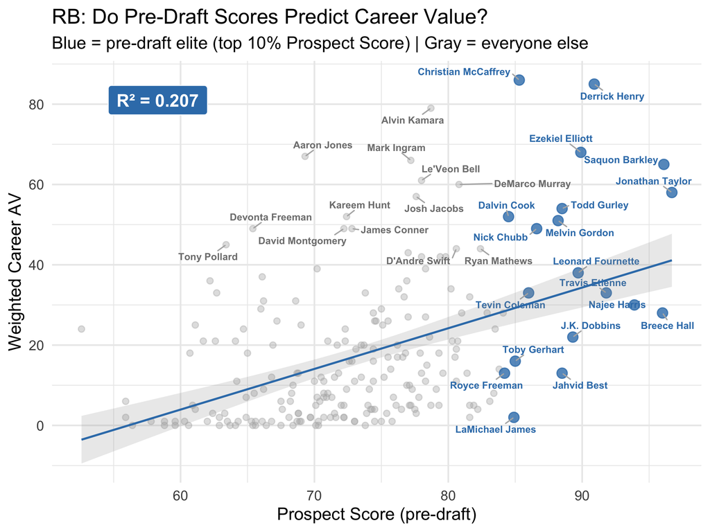

The pre-draft elite prospects (blue dots) cluster toward the upper right: high NGS scores mapping to high career value. Pre-draft elite RBs averaged **41.9** career AV, vs **15.1** for everyone else. They became starters at **68.4%** vs **14.1%**.

Not every pre-draft elite prospect panned out. Jahvid Best and LaMichael James scored elite on NGS but busted. But the signal is clear: the top of the NGS distribution produces starters at dramatically higher rates.

The same view across all positions:

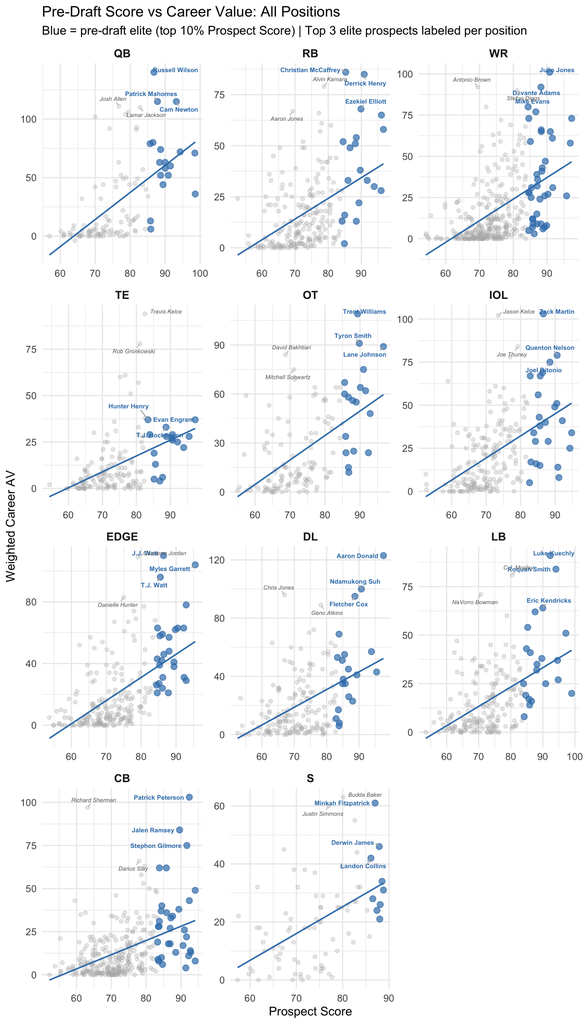

Across all positions, pre-draft elite prospects became starters at **53.5%** vs **13.5%** for everyone else. The trend line slopes upward at every position, and the pre-draft signal isn’t perfect, but it meaningfully separates prospects who become starters from those who don’t.

**Prospect Score vs Career AV: R² by Position**

How well does the pre-draft score predict career value?

| Position | n | R² | Career AV Elite Avg AV | Career AV Other Avg AV | Starter Rate Elite Hit % | Starter Rate Other Hit % |
| --- | --- | --- | --- | --- | --- | --- |
| QB | 112 | 0.350 | 66.3 | 20.3 | 77.8 | 16.0 |
| EDGE | 222 | 0.310 | 50.8 | 15.8 | 50.0 | 10.2 |
| OT | 134 | 0.308 | 53.8 | 20.3 | 66.7 | 19.8 |
| IOL | 202 | 0.258 | 41.8 | 19.2 | 62.5 | 19.1 |
| S | 88 | 0.255 | 34.8 | 18.1 | 66.7 | 20.3 |
| LB | 201 | 0.244 | 38.2 | 14.1 | 33.3 | 8.9 |
| WR | 330 | 0.234 | 37.3 | 14.3 | 48.7 | 13.7 |
| DL | 186 | 0.214 | 46.5 | 18.3 | 45.0 | 10.8 |
| RB | 217 | 0.207 | 41.9 | 15.1 | 68.4 | 14.1 |
| TE | 151 | 0.207 | 23.0 | 10.6 | 50.0 | 17.0 |
| CB | 308 | 0.187 | 31.1 | 11.4 | 42.4 | 8.7 |

### The Historical NGS Elite

Who were the highest-graded pre-draft prospects at each position, and did they deliver? Here we use the stricter bar: **top 10% of weighted career AV** at their position. Not just a starter, but a *great* player. Starting with RB:

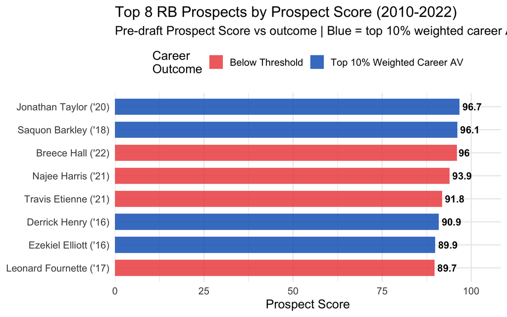

The top 8 RB prospects by pre-draft NGS score finished in the top 10% of career AV at **50%**, far above the position’s overall average. The names are what you’d expect: Jonathan Taylor, Saquon Barkley, Derrick Henry, Ezekiel Elliott. These aren’t random outcomes. the pre-draft signal identified them before a single NFL snap.

Now the same view across all positions:

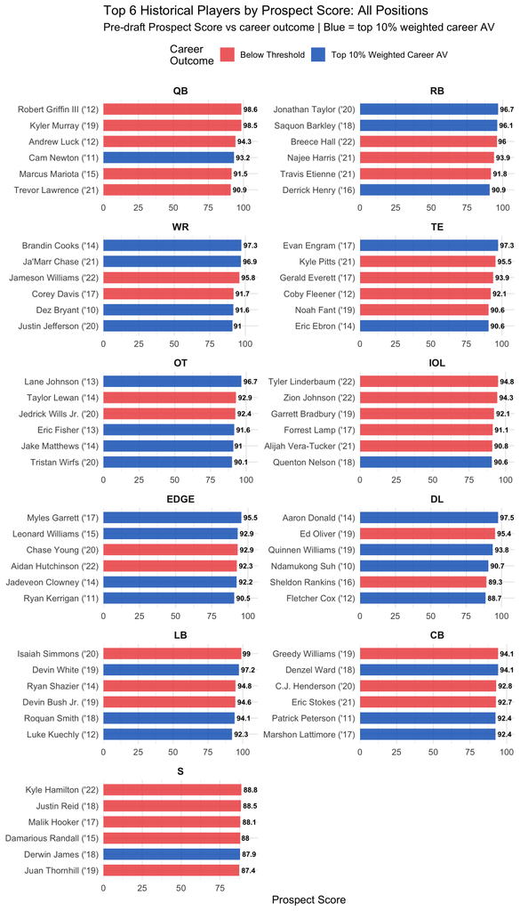

**DL** leads the pack: the top 6 NGS scorers reached top-10% weighted career AV at66.7%. **S** has the weakest pre-draft-to-career translation (16.7%). The model’s RB penalty is driven by the average prospect. When the pre-draft signal says a prospect is clearly separated from the class, they become *great* at dramatically higher rates.

## The Love Question Revisited

In Part 1, we asked: *Should you draft Jeremiyah Love at 10?*

The model said no. RB has a deeply negative Sharpe in the top 10. But we’ve now shown that the answer depends on things the model can’t see: roster needs, class depth, and prospect separation. Love is the case that brings all three together.

### The 2026 RB Class

We showed above that historical RBs with elite pre-draft NGS scores become great at dramatically higher rates than the position average. Where does Love’s 2026 class fit in?

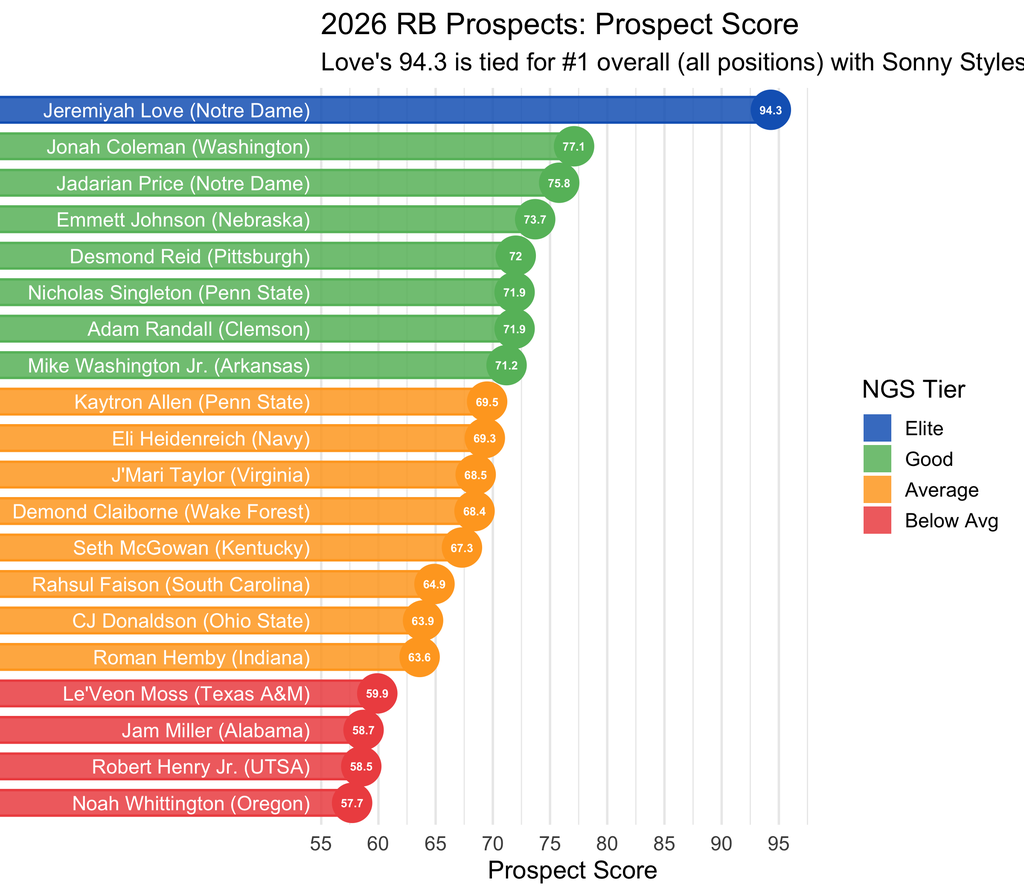

Love’s Prospect Score of **94.3** is tied for #1 overall across all positions. His Production Score of **95.9** is the highest of any prospect in the 2026 class. The gap to RB2 (Jonah Coleman at 77.1) is **17.2 points** – a chasm by NGS standards.

### Where Love Ranks in the Historical Record

How does Love’s 94.3 compare to every RB prospect since 2010? Here’s every RB with a Prospect Score, with Love highlighted:

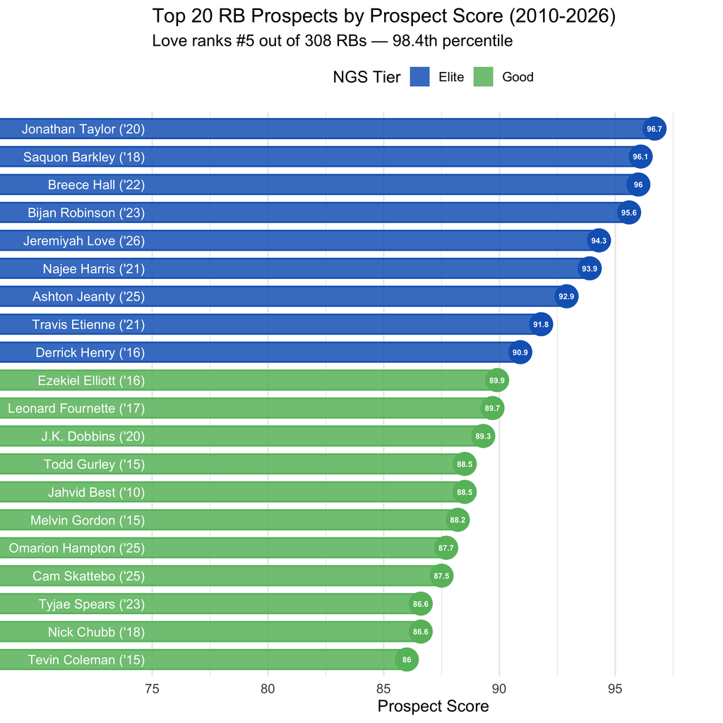

Love’s 94.3 ranks **#5** among all 308 RB prospects in the NGS era. That puts him in the **98.4th percentile**, in the company of Jonathan Taylor, Saquon Barkley, Breece Hall, and Bijan Robinson. The pre-draft signal is as strong as it gets.

But Love isn’t the only outlier in 2026. Here’s a look at the top prospect at every position:

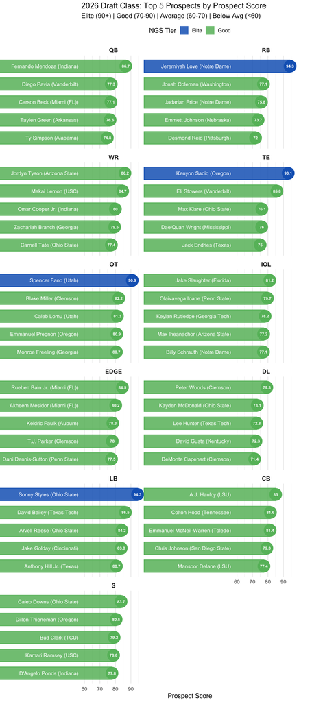

The 2026 class has fascinating separation patterns. **RB** has the biggest gap between the top prospect (Jeremiyah Love at 94.3) and #2 – a **17.2-point** chasm. Meanwhile, **WR** is the tightest race, with just a **1.5-point** gap at the top. Where a prospect is clearly separated, the elite-prospect argument gets stronger. Where the class is tightly bunched, the model’s average-case advice holds.

### The NGS Prospect Score: What It Measures

Before we build models, it’s worth understanding the inputs. NFL Next Gen Stats publishes a **Prospect Score** (officially “Combined Score”) for every draft-eligible player. It’s a composite of three machine-learning models, each position-controlled:

- **Athlete Score:** Athletic testing data from the NFL Combine and pro days (40-yard dash, vertical jump, broad jump, agility drills, and more). Pure physical measurables, adjusted for what matters at each position.
- **Production Score:** College statistical production (yards, touchdowns, snap counts, efficiency metrics). A receiver who dominated the SEC grades differently than one who put up numbers in the MAC.
- **Size Score:** Body composition relative to positional norms (height, weight, arm length, hand size). A 6’5” tackle grades differently than a 6’5” receiver.

The Prospect Score combines all three into a single number from 0 to 100. It’s published before the draft, making it one of the few rigorous, position-adjusted prospect evaluations available to GMs in real time.

### Predicting Career Value

The scatter plots show a pattern. Can we quantify it? We trained a linear regression predicting weighted career AV from only information available before the draft: the Prospect Score, draft position, and position group. All models are trained on 2010-2019 and validated out-of-time on 2020-2022.

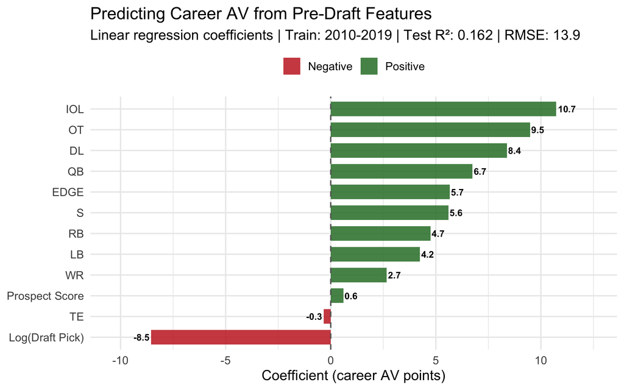

How well does this work in practice? Here are some players from the 2020-2022 test set, prospects the model never saw during training, with their predicted vs actual career AV:

**Model Check: Predicted vs Actual (2020-2022 Test Set)**

Mix of outperformers, busts, and close calls

| Player | Pos | Draft | Pick | Prospect Score | Actual AV | Predicted AV | +/- |
| --- | --- | --- | --- | --- | --- | --- | --- |
| Jalen Hurts | QB | 2020 | 53 | 85.7 | 79 | 33 | 46 |
| Justin Herbert | QB | 2020 | 6 | 88.7 | 74 | 53 | 21 |
| CeeDee Lamb | WR | 2020 | 17 | 88.3 | 65 | 40 | 25 |
| Justin Jefferson | WR | 2020 | 22 | 91.0 | 65 | 40 | 25 |
| Ja'Marr Chase | WR | 2021 | 5 | 96.9 | 58 | 56 | 2 |
| Tua Tagovailoa | QB | 2020 | 5 | 88.7 | 52 | 55 | -3 |
| DeVonta Smith | WR | 2021 | 10 | 89.5 | 47 | 46 | 1 |
| Zach Wilson | QB | 2021 | 2 | 85.8 | 13 | 61 | -48 |
| Jeff Okudah | CB | 2020 | 3 | 92.2 | 11 | 55 | -44 |
| Trey Lance | QB | 2021 | 3 | 85.9 | 6 | 58 | -52 |

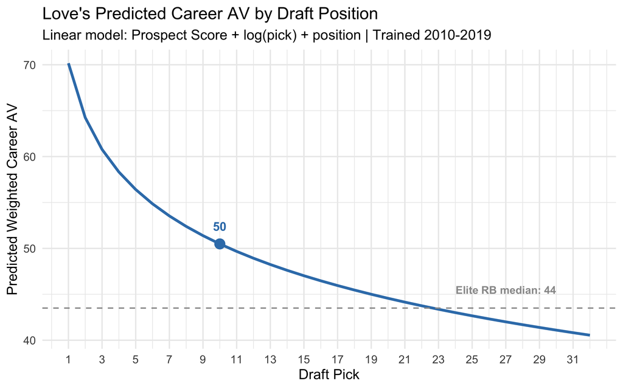

The linear model, trained on 2010-2019 and tested on the 2020-2022 classes it’s never seen (test R² = 0.162, RMSE = 13.9) — projects Love at **50** weighted career AV at pick 10. For context, the median elite RB (top 10% Prospect Score) historically produced **44** career AV. The model says Love’s pre-draft profile is worth a first-round pick.

### Did First-Round RBs Actually Outproduce the Alternative?

Article 1 gave us the Sharpe ratio for RB in the top 10: **-0.615**. That’s the average across all RBs drafted in the top 10 since 2010. But averages hide a massive range. Some first-round RBs were franchise cornerstones. Others were busts. The question isn’t whether RBs are worth it *on average* – it’s how often they outproduce the player a team could have taken instead.

Here’s every first-round RB in our data, plotted against the non-RB taken with the very next pick. The **circle** is the RB. The **yellow X** is whoever was drafted immediately after them. Green means the RB produced more career value; red means the next pick was better.

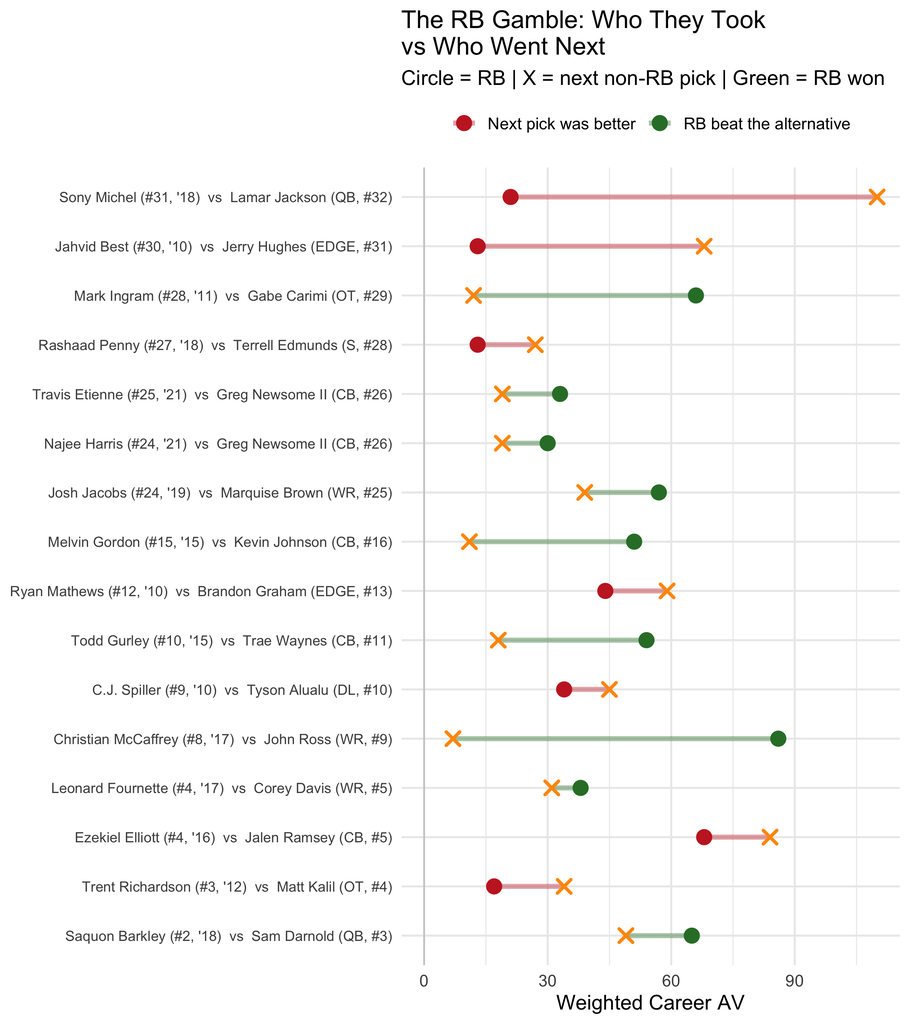

Article 1’s tier-level Sharpe for RB in the top 10 is **-0.615**, the worst of any position. The weighted career AV comparison shows why.

**The wins:** CMC (86 career AV) vs John Ross (WR, 7). Gurley (54) vs Trae Waynes (CB, 18).

**The losses:** Trent Richardson at pick 3 (17 career AV). The next pick was **Matt Kalil** (OT, 34 career AV).

Only **56%** of first-round RBs outproduced the very next non-RB drafted. Love needs to be in the CMC/Gurley tier, not the Richardson tier, to justify the pick.

### The Negative-Sharpe Picks: What Teams Left on the Table

The Sharpe ratio flags specific position-tier combinations as negative, plays the model says teams shouldn’t make. Since 2010, **135 first-round picks** went to non-premium positions at tiers where the Sharpe ratio was negative. But what actually happened to the next premium player taken? Instead of a theoretical counterfactual, we tracked the real one: for each negative-Sharpe pick, we found the actual next QB, EDGE, OT, or WR drafted in the same year and compared outcomes.

**Negative-Sharpe First-Round Picks (2010-2022)**

128 picks at negative-Sharpe combos vs the actual next QB/EDGE/OT/WR drafted

| Position | Picks | Avg Pick | What They Got Career AV | What They Got Surplus ($M) | What They Got Hit % | What They Got Elite % | Next Premium Player Taken Career AV | Next Premium Player Taken Surplus ($M) | Next Premium Player Taken Hit % | Next Premium Player Taken Elite % | Surplus Δ ($M) |  |
| --- | --- | --- | --- | --- | --- | --- | --- | --- | --- | --- | --- | --- |
| IOL | 34 | 18.1 | 38.4 | 43.0 | 53.8 | 20.6 | 34.3 | 91.3 | 50.0 | 14.7 |  | -48.3 |
| LB | 33 | 16.2 | 42.5 | 48.8 | 40.0 | 30.3 | 30.7 | 80.4 | 46.9 | 12.1 | -31.6 |  |
| CB | 17 | 6.6 | 41.8 | 59.8 | 53.3 | 47.1 | 50.2 | 96.9 | 76.5 | 23.5 | -37.1 |  |
| RB | 16 | 16.0 | 43.1 | 48.1 | 56.2 | 43.8 | 46.4 | 95.3 | 60.0 | 31.2 | -47.2 |  |
| S | 11 | 17.7 | 31.6 | 48.1 | 45.5 | 27.3 | 31.6 | 77.4 | 9.1 | 18.2 | -29.3 |  |
| TE | 10 | 18.0 | 25.7 | 41.2 | 60.0 | 60.0 | 41.0 | 83.0 | 50.0 | 30.0 | -41.8 |  |

Since 2010, **135 first-round picks** went to position-tier combos where the Sharpe ratio was negative, plays Article 1’s model explicitly flags as bad bets. For **128** of those, we found the actual next premium-position player (QB, EDGE, OT, or WR) taken in the same draft. Those negative-Sharpe picks averaged **40** career AV and **$49.2M** in surplus value. The next premium player taken averaged **38** career AV and **$85.8M** in surplus, a gap of **-$36.6M**.

RB specifically: **16 first-round RBs** at negative-Sharpe tiers, averaging **$48.1M** in surplus vs **$95.3M** for the next premium player actually drafted (Δ = -$47.2M). The surplus gap is the dagger: it’s the value teams left on the table by taking the ‘wrong’ position. For RBs, the next premium player generated more surplus, confirming the Sharpe ratio’s warning.

Why are these numbers so large? Surplus value is driven by the gap between a rookie contract and free-agent replacement cost, compounded over four years. Consider the 2018 draft: Saquon Barkley (pick 2) earned ~4.4% of the cap on his rookie deal, while a replacement RB costs ~6%, a savings of just ~$4M/yr. Sam Darnold (pick 3) earned ~4.3%, but a replacement QB costs ~14.6%, a savings of ~$26M/yr. Over four years, Darnold’s rookie surplus alone (~$120M in today’s cap terms) dwarfs Barkley’s (~$19M), even though Darnold’s rookie contract years with the Jets were a disaster. The cost-controlled advantage at positions with expensive free-agent markets is so massive that even a mediocre QB outcome beats a great RB outcome in surplus terms.

### The Surplus Value View

Since Part 1 showed that surplus value tends to lead to higher win percentage and more frequent playoff berths, we return to it in order to determine where exactly Love should go this year. The optimal place for Love to go is one where it’s reasonable to project that his range of outcomes could potentially make the opportunity cost worth it. Now let’s put Love through the same lens. The formula:

> **Surplus Value** = Rookie Surplus + Second Contract APY (as % of cap)

Where rookie surplus = snap ratio × (FA replacement cost − rookie deal APY) × 4 years. A QB on a rookie deal saves ~10% of the cap per year vs free agency; an RB saves ~1.6%. Over four years, that difference alone is worth ~$90M in today’s terms, before we even get to second contracts.

Instead of predicting player return as a single number, we decompose it into its components (two modeled, two known):

1. **Snap ratio** (quantile regression): predicts how much a player will play from Prospect Score, draft position, and position. OLS R² = 0.332. This is what scouting grades should actually predict.
2. **Second contract value** (quantile regression): predicts the market’s verdict after the rookie deal.
3. **FA replacement cost:** known by position (QB = 14.6% of cap, RB = 6.0%, EDGE = 9.1%).
4. **Rookie deal APY:** known by pick from the CBA rookie wage scale.

We use quantile regression at the 10th, 50th, and 90th percentiles for both modeled components. This lets us assemble floor, median, and ceiling outcomes for any prospect:

> *Player Return = Snap Ratio × (FA Cost − Rookie APY) × 4 + Second Contract*

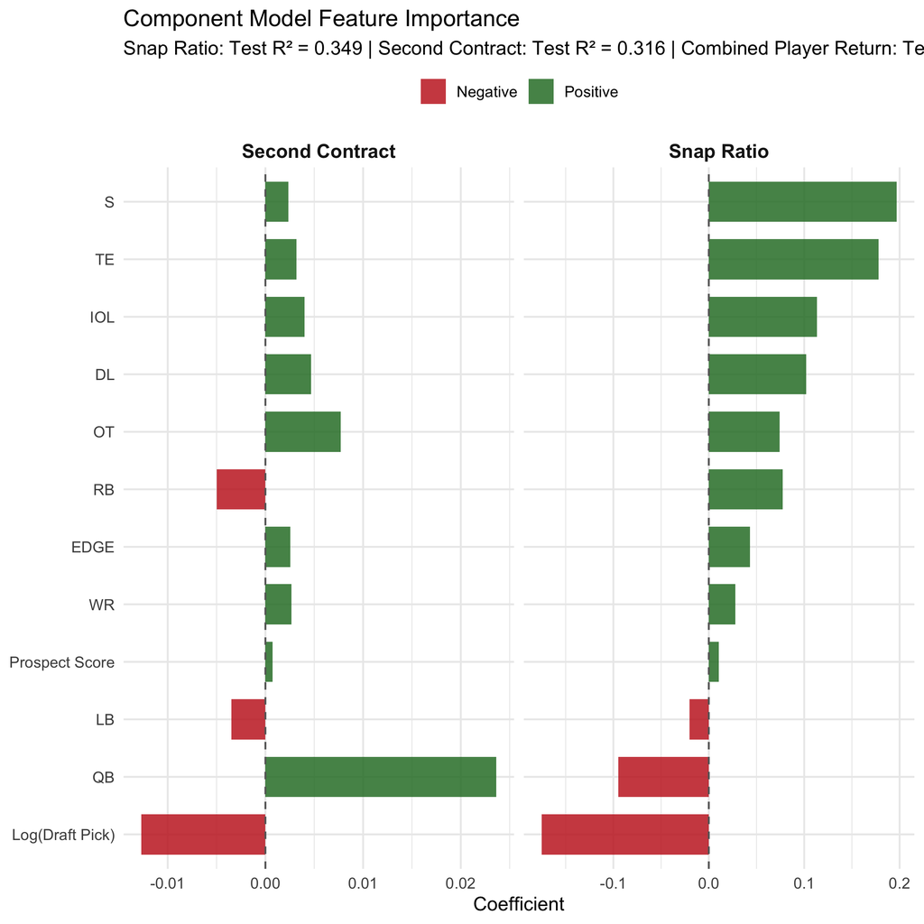

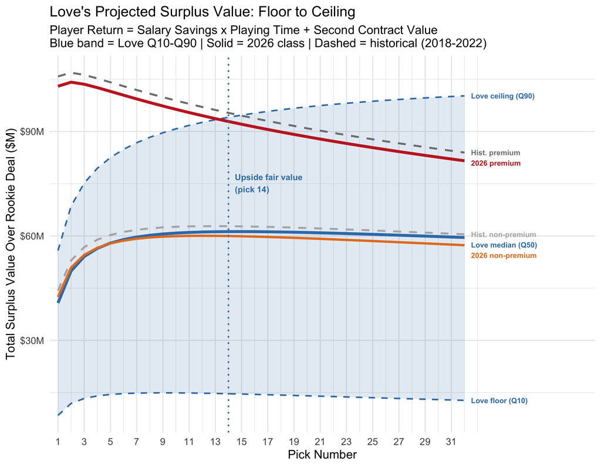

The chart confirms what the counterfactual data already told us: the surplus gap is structural. Love’s median outcome (solid blue) runs well below the premium position average at every pick. The Sharpe ratio’s core argument holds up.

But the ceiling tells a different story. There are two paths through the surplus math: **high snap ratio** and a **big second contract**. An RB who plays 90%+ of snaps and earns a market-resetting second deal can close most of the structural gap. Love’s 90th-percentile outcome crosses the premium position average at **pick 14**. That’s the narrow window where the bet makes sense.

At pick 10, Love’s median surplus is **$60.8M** vs **$96.4M** for the premium position average — a gap of **$35.5M**. Even when career production is comparable, premium positions generate more surplus because free-agent replacements cost so much more. The Sharpe ratio’s framework is doing exactly what it was built to do.

The ceiling case is the only path through. Love’s 90th-percentile outcome — a Gurley/CMC-level career with elite snap share and a market-resetting second contract — crosses the premium position average at **pick 14**. That’s the bet: a team drafting Love after pick 14 isn’t ignoring the surplus math. They’re betting that his talent ceiling is high enough to overcome it.

This is where the stress test lands. The Sharpe ratio’s position economics are sound. But the framework assumes an average prospect at each position. Love isn’t average — and the gap between his talent and the next RB in this class is wide enough to matter.

### Which Teams Actually Need an RB?

We showed earlier that having a back on the depth chart isn’t the same as having the position filled. RB is a high-turnover position. Backs get hurt, decline fast, and cycle through rosters more than QBs or OTs. A team can enter the offseason with an “RB1” on the depth chart and still have a genuine need if that back is a committee player, a career backup, or an aging veteran without a long-term future.

Here’s what every team’s RB room looks like heading into the 2026 draft, based on current depth charts.

**2026 RB Room Snapshot**

Current depth charts via OurLads | Sorted by need then pick

| Team | R1 Pick | RB1 | RB2 | RB3 | Status |
| --- | --- | --- | --- | --- | --- |
| ARI | 3 | Tyler Allgeier | James Conner | Trey Benson | Need |
| TEN | 4 | Tony Pollard | Tyjae Spears | Michael Carter | Need |
| NYG | 5 | Cam Skattebo | Tyrone Tracy Jr. | Devin Singletary | Need |
| WAS | 7 | Rachaad White | Jerome Ford | Jacory Croskey-Merritt | Need |
| MIN | 18 | Aaron Jones Sr. | Jordan Mason | Zavier Scott | Need |
| CAR | 19 | Chuba Hubbard | Jonathon Brooks | Trevor Etienne | Need |
| JAX | 24 | Bhayshul Tuten | LeQuint Allen Jr. | Chris Rodriguez Jr. | Need |
| NE | 31 | Rhamondre Stevenson | TreVeyon Henderson | Lan Larison | Need |
| SEA | 32 | Zach Charbonnet | Emanuel Wilson | George Holani | Need |
| LV | 1 | Ashton Jeanty | Dylan Laube | Chris Collier | Filled |
| NYJ | 2 | Breece Hall | Braelon Allen | Isaiah Davis | Filled |
| CLE | 6 | Quinshon Judkins | Dylan Sampson | Raheim Sanders | Filled |
| NO | 8 | Travis Etienne Jr. | Alvin Kamara | Kendre Miller | Filled |
| KC | 9 | Kenneth Walker | Brashard Smith | Emari Demercado | Filled |
| CIN | 10 | Chase Brown | Samaje Perine | Tahj Brooks | Filled |
| MIA | 11 | De'Von Achane | Jaylen Wright | Ollie Gordon II | Filled |
| DAL | 12 | Javonte Williams | Malik Davis | Jaydon Blue | Filled |
| ATL | 13 | Bijan Robinson | Brian Robinson | Tyler Goodson | Filled |
| BAL | 14 | Derrick Henry | Justice Hill | Rasheen Ali | Filled |
| TB | 15 | Bucky Irving | Kenneth Gainwell | Sean Tucker | Filled |
| IND | 16 | Jonathan Taylor | DJ Giddens | Ulysses Bentley IV | Filled |
| DET | 17 | Jahmyr Gibbs | Isiah Pacheco | Jacob Saylors | Filled |
| GB | 20 | Josh Jacobs | Chris Brooks | MarShawn Lloyd | Filled |
| PIT | 21 | Jaylen Warren | Rico Dowdle | Kaleb Johnson | Filled |
| LAC | 22 | Omarion Hampton | Keaton Mitchell | Kimani Vidal | Filled |
| PHI | 23 | Saquon Barkley | Tank Bigsby | Will Shipley | Filled |
| CHI | 25 | D'Andre Swift | Kyle Monangai | Roschon Johnson | Filled |
| BUF | 26 | James Cook III | Ty Johnson | Ray Davis | Filled |
| SF | 27 | Christian McCaffrey | Jordan James | Isaac Guerendo | Filled |
| HOU | 28 | David Montgomery | Woody Marks | Jawhar Jordan | Filled |
| LA | 29 | Kyren Williams | Blake Corum | Ronnie Rivers | Filled |
| DEN | 30 | J.K. Dobbins | RJ Harvey | Jaleel McLaughlin | Filled |

### Putting It All Together: Who Should Draft Love?

Everything we’ve built in this article converges on a single question. Which teams are in the best position to draft Jeremiyah Love?

There’s one more factor the surplus math can’t see: **RBs peak early and decline fast.** We use fantasy points here because they give us a clean, position-comparable measure of on-field production that tracks how much a player actually contributes to offensive output season over season. It’s the simplest way to see when a player is delivering peak value.

The last piece is who is ready to take advantage of that production right away.

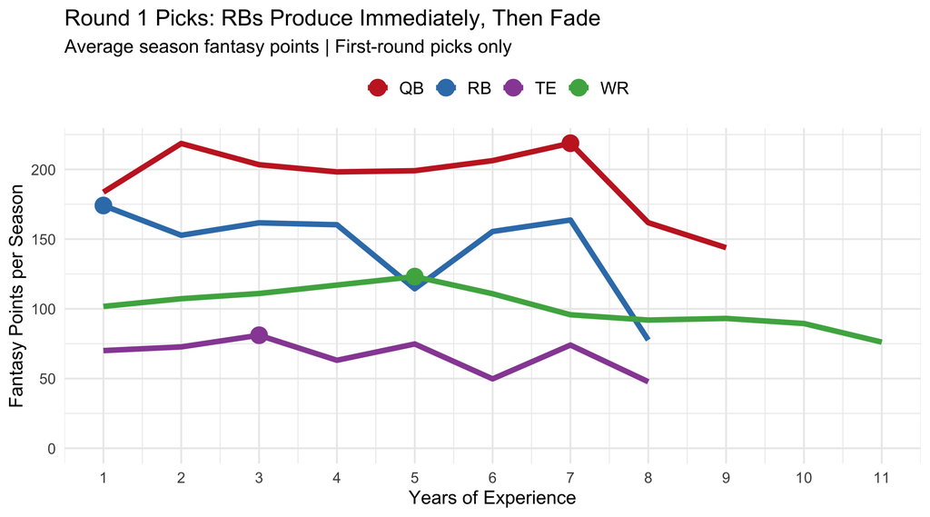

Anecdotally, the Vikings at pick 18 make the most sense. They are ready to make another run in the playoffs if we see Kyler Murray’s new change of scenery help him return to his early career level of play.

So the picture comes into focus. Love’s ceiling crosses the premium surplus line at **pick 14**. RBs peak early and decline fast. And nine teams need a running back.

**The sweet spot — teams that need an RB and pick at 14 or later:**

- **MIN (pick 18):** Aaron Jones Sr., Jordan Mason, Zavier Scott
- **CAR (pick 19):** Chuba Hubbard, Jonathon Brooks, Trevor Etienne
- **JAX (pick 24):** Bhayshul Tuten, LeQuint Allen Jr., Chris Rodriguez Jr.
- **NE (pick 31):** Rhamondre Stevenson, TreVeyon Henderson, Lan Larison
- **SEA (pick 32):** Zach Charbonnet, Emanuel Wilson, George Holani

These teams check every box. They need a back, they pick where the upside math works, and they’re close enough to contention to use Love’s peak years.

**The harder call — ARI (3), TEN (4), NYG (5), WAS (7):**

The other 23 first-round teams already have a productive RB. For them, the Sharpe model’s advice is unchanged: draft a premium position.

## What the Stress Test Found

The Sharpe ratio works. The positional hierarchy held up under every test we threw at it: QB, EDGE, OT, and WR generate more surplus than non-premium positions, and the counterfactual data confirms it. The surplus gap is real and staggering. This article didn’t disprove the framework — it stress-tested it and found it sturdy.

But we also found three conditions that turn Part 1’s general RB advice from a universal rule into a conditional one:

1. **Roster context matters.** Having a name on the depth chart isn’t the same as having the position filled. Nine teams enter 2026 without a long-term answer at RB. For them, the opportunity cost of *not* drafting one is higher than the model assumes.
2. **Class depth varies wildly.** The 2026 RB class is thin — Love is the only Elite prospect. Pass on him and there’s no comparable alternative in round 2 or 3. Meanwhile, IOL, CB, and WR are loaded. The positions the model says to take instead will still be available later. The RB won’t be.
3. **Not all prospects are average.** Love’s 94.3 Prospect Score ranks 5th among all RB prospects since 2010. The model averages over all RBs. Love isn’t average. His 90th-percentile surplus outcome crosses the premium position average at pick 14 — and RBs produce immediately, peaking in their first two years while QBs and WRs are still developing.

**What still holds:** QB is still king. The surplus math still favors premium positions before pick 14. Day 2+ RBs are still the default when the class isn’t thin. The Sharpe ratio is a good framework — one of the best tools we have for draft strategy. It just can’t see the difference between “RB” and “*this* RB, in *this* class, for *this* team.”

**The bottom line:** The Sharpe ratio is right that premium positions generate more surplus, and the data backs it up convincingly. But within that framework, there’s a narrow path for Love. Nine teams need a running back. The 2026 class is thin. Love is separated from every other RB prospect by 17 points. His ceiling crosses the premium surplus line at **pick 14**. And RBs produce immediately — Love’s peak years align with the rookie contract window.

The best fits are **MIN (18), CAR (19), JAX (24), NE (31), SEA (32)** — teams that need a back, pick where the upside math works, and can’t find a comparable RB later in this thin class. For a team like **MIN (18)** — aging Aaron Jones, no long-term answer — Love is a reasonable first-round pick, not in spite of the Sharpe ratio, but because the framework leaves room for exactly this kind of exception: elite talent, genuine need, no alternative.

## Coming in Part 3: How Sharpe Was Your Draft?

Parts 1 and 2 gave us the framework and the context. After the draft, we’ll put them together and grade every team’s picks. Not “did you draft good players?” — we can’t know that yet — but “did you make Sharpe-optimal decisions given what we know?”

Each pick gets scored on four dimensions: Was it a positive-Sharpe position for that tier? Did it fill a genuine roster need? Was the class deep enough that you could have waited? And if you took a non-premium position, was the prospect clearly separated from the field?

The Love pick — wherever it lands — will be the headline test case. But every first-round pick tells a story about how a front office weighs position economics against context. We’ll find out who followed the model, who broke the rules for good reasons, and who left surplus on the table.

## Methodology Notes

**Data:** Player stats from Pro Football Reference via `nflreadr`. Contract data from OverTheCap via `nflreadr`. All values normalized to percentage of salary cap at time of signing. Analysis covers 2010-2022 draft classes (minimum 4 NFL seasons for fair evaluation).

**Hit definition (Article 1):** Snap-based quality measure. A “hit” is a player who plays above the positional snap threshold (75% of baseline snaps for their position). This measures whether a player became a starter.

**Elite outcome measure:** For comparing elite categories, we use Article 1’s snap-based hit rate as the outcome (independent of career AV, which defines the career elite group). [Weighted Career Approximate Value](https://www.pro-football-reference.com/about/approximate_value.htm) (weighted career AV) from Pro Football Reference — which weights toward peak seasons — is used for defining career elite prospects (top 10% at position) and for individual player comparisons in the dumbbell chart.

**Elite classification:** Two definitions used. Retrospective: top 10% of weighted career AV within each position group. Prospective: top 10% of Prospect Score within each position group. Players meeting both criteria had the highest elite outcome rates.

**Prospect Score:** NFL Next Gen Stats composite prospect score combining athletic testing, college production, and size metrics. Published pre-draft. Historical scores matched to draft records via normalized name and position group.

**Class depth:** A class is “deep” if its count of Good+ prospects (Prospect Score >= 70) exceeds the position’s median Good+ count across all years. “Thin” if below the median.

**Roster needs:** A position is “filled” if the team had a starter who played above the hit threshold, earned a second contract above the free-agent replacement cost for the position, and was not on an expiring deal. A position is a “need” if it wasn’t filled.

**Predictive models:** Two models trained on players drafted 2010-2019 with Prospect Scores and career outcomes, validated out-of-time on the 2020-2022 classes. Features: Prospect Score, log(draft pick), and position group. Draft pick is log-transformed because draft value declines non-linearly. (1) Linear regression predicting weighted career AV. (2) Component-based player return model using quantile regression (10th/50th/90th percentiles) for snap ratio and second contract value, combined with known FA replacement costs and CBA rookie wage scale. Athlete Score and Production Score (sub-components of Prospect Score) were tested but excluded — neither was significant when the composite Prospect Score was already in the model.

**Part 1:** Full methodology and interactive charts at [stranger9977.github.io/draft-sharpe-analysis](https://stranger9977.github.io/draft-sharpe-analysis/)

*Built with R, ggplot2, nflplotR, and gt. Data from nflverse and Pro Football Reference.*